# Group AA Milestone 6

2022-12-11

### Problem statement

Smoking cigarettes can damage the body’s organs, increase the risk of numerous illnesses, and generally harm people’s health. The most common preventable cause of mortality in the U.S. is smoking cigarettes. Smoking is linked to numerous cancers, heart conditions, strokes, respiratory conditions such chronic obstructive pulmonary disease, diabetes, and other disorders. However, some smokers are more vulnerable to these negative effects than others. The question we explored is “what characteristics and behaviors among smokers in California lead to adverse health outcomes?”

At any age, even among heavy and longtime smokers, quitting smoking can have a significant positive impact on both short- and long-term health. For the prevention and cessation of smoking, a range of therapies are successful. With the use of data from the 2011 California Smokers’ Cohort (CSC), the California Tobacco Surveys (CTS), we may better understand the tobacco use and smoking habits of Californian smokers and put initiatives into place in high-risk areas to encourage quitting.

### Methods

In the 2011 CSC study, 1,000 smokers completed the follow up survey and were included in the data set for analysis. We cleaned the data for analysis of 5 selected health outcomes, as well as select demographic variables. Our data were originally split in two data sets, which we combined by merging on the patient ID variable. Once that was finalized we cleaned and analyzed the data by factoring all variables that were characters, combining all race variables into one column, accounting for missing variables, and calculating pack years. The study population did not have a very diverse racial/ethnic spread, so we decided to exclude race in our analysis. We decided to focus on health outcomes and the stratification by income level, and subset our data accordingly to include variables that would be of importance in our visualizations and analysis. We also created new variables to categorize income into low, medium, and high income, as well as one to categorize pack years to “average”, “above average”, and “below average” pack years.

### Visualizations

#### Visual 1: Table One of Pack Years and Health Outcomes

```
##                          Stratified by Above/Below Average Pack Years
##                           level above average average        below average
##   n                               317             5            503
##   Pack Years (mean (SD))        39.50 (16.86) 22.00 (0.00)   10.44 (6.10)
##   Asthma (%)              No      254 (80.1)      2 ( 40.0)    403 (80.1)
##                           Yes      63 (19.9)      3 ( 60.0)    100 (19.9)
##   Diabetes (%)            No      274 (87.3)      5 (100.0)    473 (94.0)
##                           Yes      40 (12.7)      0 (  0.0)     30 ( 6.0)
##   Heart Disease (%)       No      274 (87.3)      5 (100.0)    473 (94.0)
##                           Yes      40 (12.7)      0 (  0.0)     30 ( 6.0)
##   Other Mental Health (%) No      255 (81.7)      4 ( 80.0)    406 (81.2)
##                           Yes      57 (18.3)      1 ( 20.0)     94 (18.8)
##                          Stratified by Above/Below Average Pack Years
##                           p      test
##   n
##   Pack Years (mean (SD))  <0.001
##   Asthma (%)               0.083
##
##   Diabetes (%)             0.003
##
##   Heart Disease (%)        0.003
##
##   Other Mental Health (%)  0.979
##
```

Pack Years and Health Outcomes Stratified by Above/Below Average Pack Years

|  | level | above average | average | below average | p | test |
| --- | --- | --- | --- | --- | --- | --- |
| n |  | 317 | 5 | 503 |  |  |
| Pack Years (mean (SD)) |  | 39.50 (16.86) | 22.00 (0.00) | 10.44 (6.10) | <0.001 |  |
| Asthma (%) | No | 254 (80.1) | 2 ( 40.0) | 403 (80.1) | 0.083 |  |
|  | Yes | 63 (19.9) | 3 ( 60.0) | 100 (19.9) |  |  |
| Diabetes (%) | No | 274 (87.3) | 5 (100.0) | 473 (94.0) | 0.003 |  |
|  | Yes | 40 (12.7) | 0 ( 0.0) | 30 ( 6.0) |  |  |
| Heart Disease (%) | No | 274 (87.3) | 5 (100.0) | 473 (94.0) | 0.003 |  |
|  | Yes | 40 (12.7) | 0 ( 0.0) | 30 ( 6.0) |  |  |
| Other Mental Health (%) | No | 255 (81.7) | 4 ( 80.0) | 406 (81.2) | 0.979 |  |
|  | Yes | 57 (18.3) | 1 ( 20.0) | 94 (18.8) |  |  |

#### Visual 2: Outcome and Income Cross Tabulations

| Cross Tab of Asthma Status x Income Level Asthma_status | Cross Tab of Asthma Status x Income Level Income Level High Income | Cross Tab of Asthma Status x Income Level Income Level Middle Income | Cross Tab of Asthma Status x Income Level Income Level Low Income | Cross Tab of Asthma Status x Income Level Total |
| --- | --- | --- | --- | --- |
| No | 187 | 290 | 285 | 762 |
| Yes | 30 | 49 | 97 | 176 |
| Total | 217 | 339 | 382 | 938 |

| Cross Tab of Heart Disease Status x Income Level | Cross Tab of Heart Disease Status x Income Level Heartdis_status | Cross Tab of Heart Disease Status x Income Level Income Level High Income | Cross Tab of Heart Disease Status x Income Level Income Level Middle Income | Cross Tab of Heart Disease Status x Income Level Income Level Low Income | Cross Tab of Heart Disease Status x Income Level Total |
| --- | --- | --- | --- | --- | --- |
| 2 | No | 202 | 319 | 337 | 858 |
| 3 | Yes | 14 | 20 | 43 | 77 |
| 4 | Total | 216 | 339 | 380 | 935 |

| Cross Tab of Diabetes Status x Income Level | Cross Tab of Diabetes Status x Income Level Diabetes_status | Cross Tab of Diabetes Status x Income Level Income Level High Income | Cross Tab of Diabetes Status x Income Level Income Level Middle Income | Cross Tab of Diabetes Status x Income Level Income Level Low Income | Cross Tab of Diabetes Status x Income Level Total |
| --- | --- | --- | --- | --- | --- |
| 2 | No | 202 | 319 | 337 | 858 |
| 3 | Yes | 14 | 20 | 43 | 77 |
| 4 | Total | 216 | 339 | 380 | 935 |

#### Visual 3: Of those who do have health outcomes, how are they distributed by income status. How are those that do not have health outcomes distributed by income?

Prevalence of Asthma, Heart Disease and Diabetes Stratified by Income Status

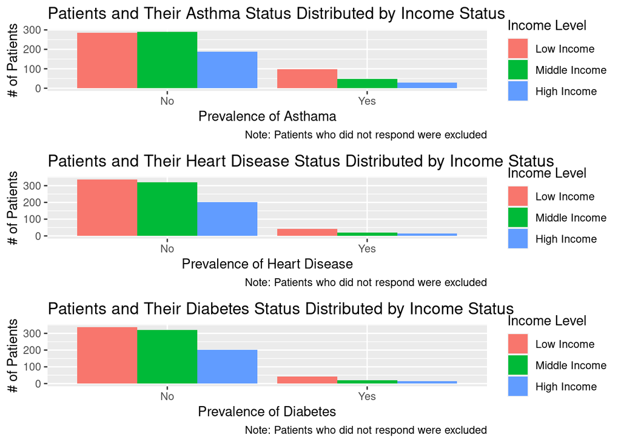

### Discussion

Additionally, we found that a person reporting average, below average, or above average pack years does not strongly correlate with disease outcome. Those who reported above-average pack years were no more likely to report asthma (19.9%) or mental health issues (18.3%) than those with below average pack years (19.9% and 18.8%). However, those with above average pack years were more likely to report diabetes (12.7%) than those with below average pack years (6%) and more likely to report heart disease (12.7%) than those with below average pack years (6%).

Based on these findings, our recommendation for CDPH would be to prioritize quitting and smoking prevention campaigns and programs among lower income communities. We would not recommend campaigns to decrease smoking (and therefore pack years) since pack years did not seem to have as large of an effect on disease outcome. This recommendation for interventions targeted towards certain populations is aimed at attempting to reduce health disparities since based on our results, those in lower income groups are more likely to report negative health outcomes than those in higher income groups.